# Health Equity Though Breast Cancer Patient Data

Lilith Appel, Jacob Posner, Mateo Useche

2024-05-02

# Introduction

Exploring hospital access and healthcare equality through breast cancer patients.

## Background

Healthcare accessibility and quality of care are not uniformly distributed in the United States, with different demographics experiencing discrepancies in their health outcomes. Furthermore, factors like race, gender, and socioeconomic status can exacerbate existing disparities regarding patient outcomes. For instance, Dubay and Lebrun (2012) find that Black and Hispanic people have worse health outcomes compared to white people in the same socioeconomic status. Therefore, it is important to extend the conversation to what other factors contribute to healthcare inequities in the United States.

A serious concern, in the United States, is why women with different demographic backgrounds have such stark differences between their diagnoses. Mootz et al., (2020) find that women with lower socioeconomic status and being uninsured are associated with higher mortality rates. Our paper wants to expand what is currently known about women’s breast cancer diagnoses and focus on additional potential factors that could influence a patient’s correct diagnosis within 90 days of a doctor’s visit. Therefore, we ask, among patients who were diagnosed with breast cancer from 2015-2018, what parameters affect whether or not a breast cancer patient was diagnosed within 90 days of their first hospital visit.

## Motivation

Personally, we are motivated to look into this because health accessibility has a huge impact on people’s lives, and investigating possible inequalities will hopefully lead to more equitable healthcare.

# Data Background

For this analysis, we used two different datasets that contained information at either the patient level or the hospital level:

- Health Verity (HV) Dataset
  - Healthcare-related ecosystem specifically for U.S. data
  - Created by a Kaggle challenge containing multiple data sets including health predictors, demographics, socioeconomic status, and zip codes
  - Has patient-level data for individuals who were diagnosed with metastatic triple-negative breast cancers
  - Breast cancer diagnosis with 90 days as “1” yes or “0” no
- Hospital Dataset
  - Contains data from all 50 U.S. states and territories
  - Geocoded and licensed by the U.S. Government Works

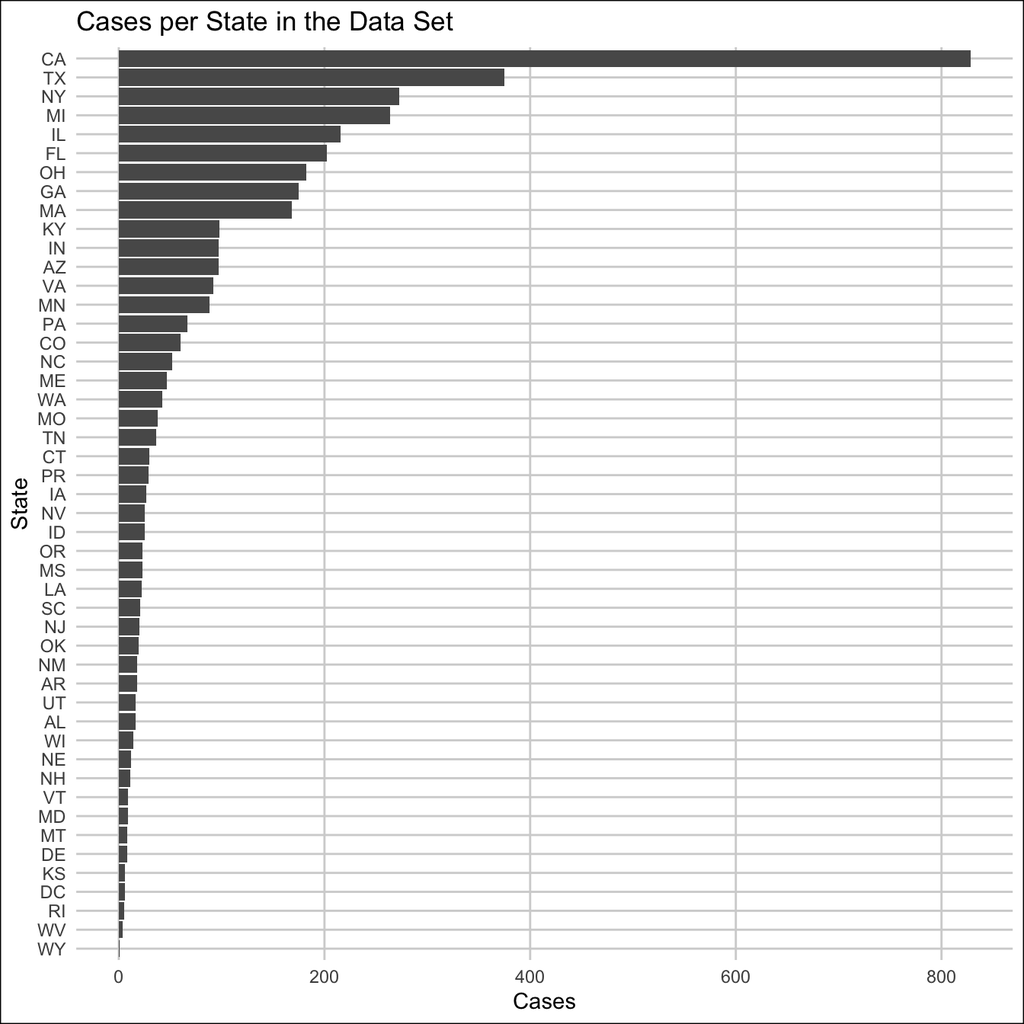

Our main outcome of interest is whether or not a patient got diagnosed with breast cancer within the first 90 days of their hospital visit, and we will use our 76 predictors to see what factors influence our dependent variable the most.

# Data Vizualization

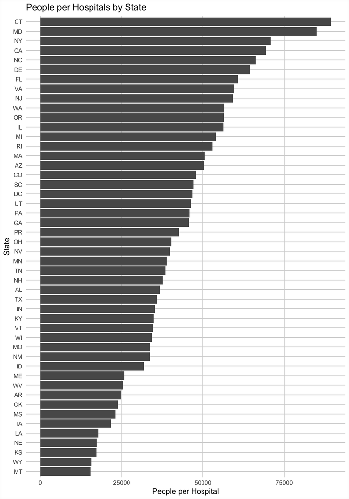

Connecticut and Maryland have the most people per hospital which means that there is limited hospital access in those states.

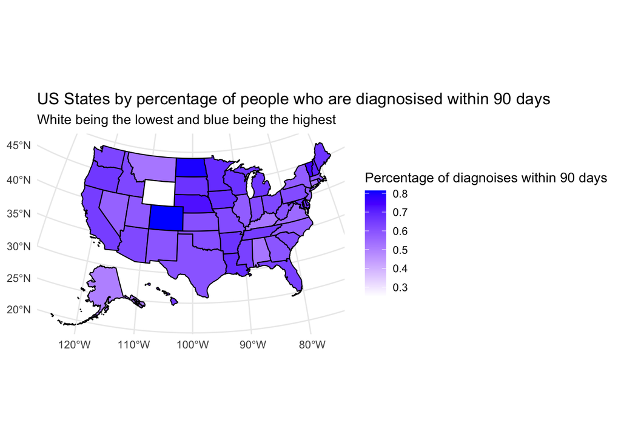

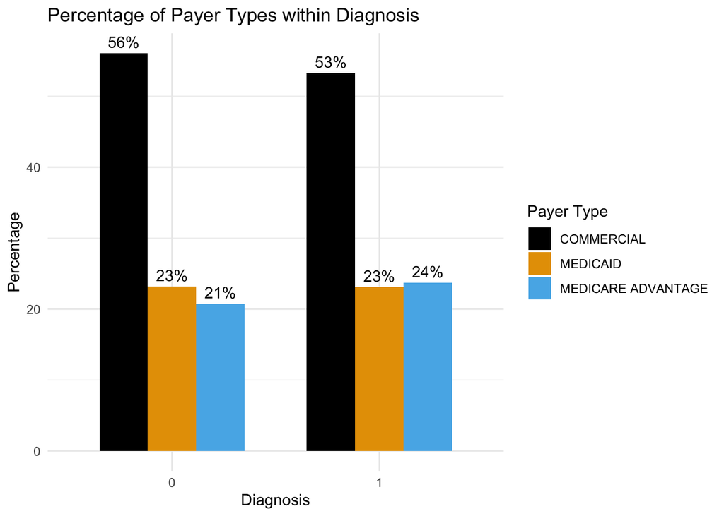

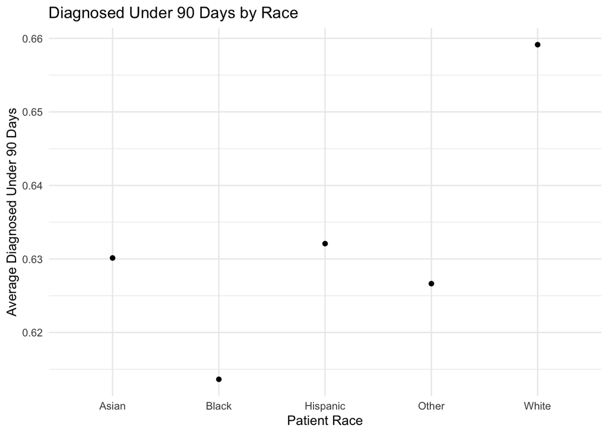

While the averages are somewhat close, we notice that white people get diagnosed within 90 days more than any other race while black people are diagnosed before 90 days at lower rates.

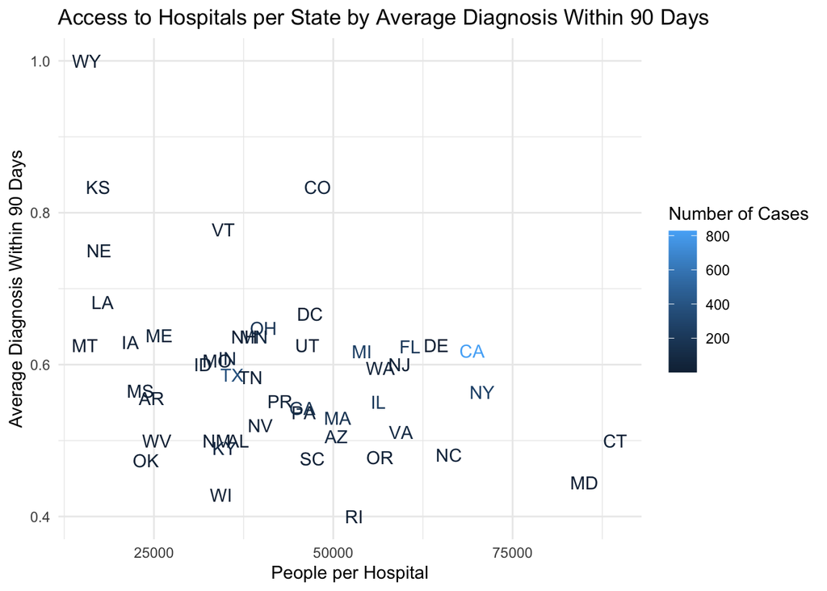

While there are several outliers due to data limitations, we notice that California and New York, who have less hospital access than other states and around average success rates, have a large number of cases in the dataset.

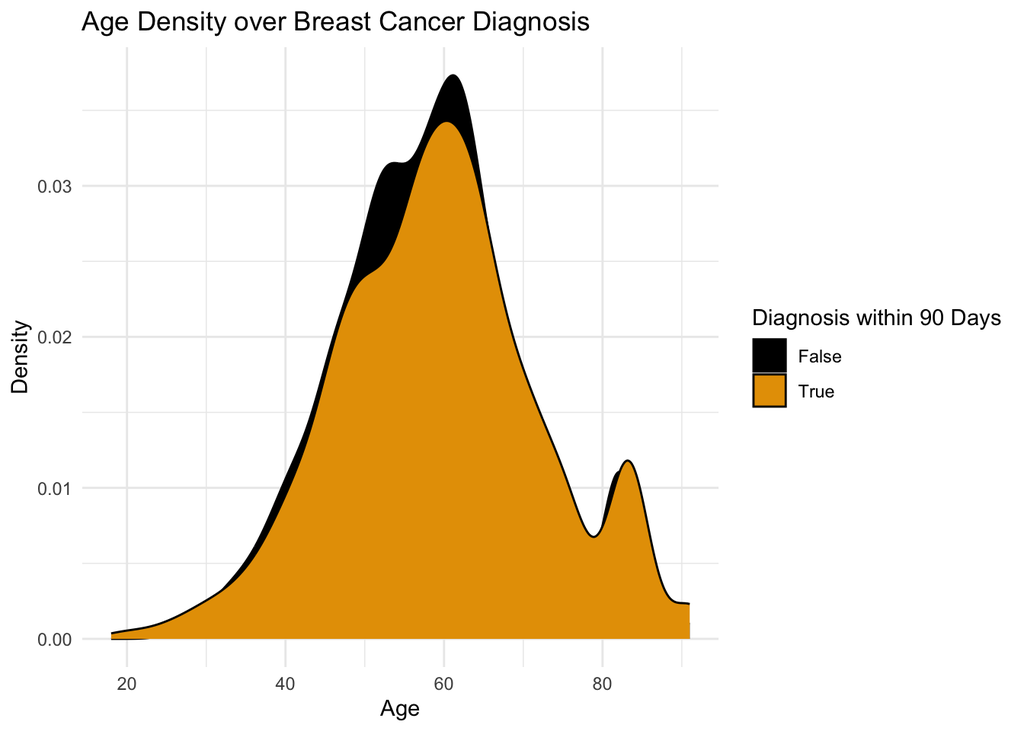

We see that people around age 60 are more likely to have breast cancer but there isn’t really a difference between a diagnosis within 90 days and age.

# Methodology

## Preliminary Model

- Type of Insurance
- Race
- Age
- Zip-code.

Since these variables seemed relevant in our raw data, we included them in our Bayesian Model. Our model assumes that our data follows a Bernoulli Distribution, which aligns with the binary nature of our dependent variable – whether or not a patient was diagnosed within 90 days of their first hospital visit. Our priors take the form of weakly informative priors which is the default in Rstan, meaning that since we do not have actual background information to include in our model, we take the default.

- $\beta_{c0}$
- $\beta_1$
- $\beta_2$
- $\beta_3$
- $\beta_4$

$$\begin{array}{lrll}
\text{Data: } & Y_i | \beta_0, \beta_1,\beta_2,\beta_3,\beta_4 &
\stackrel{ind}{\sim} \text{Bern}(\pi_i) & \text{where }
\log\left(\frac{\pi_i}{1 - \pi_i}\right) = \beta_0 + \beta_1X_{1i} +
\beta_2X_{2i} + ... + \beta_4 X_{4i} \\
&&& \text{equivalently, } \frac{\pi_i}{1 - \pi_i} =
e^{\beta_0 + \beta_1X_{1i} + \beta_2X_{2i} + ... + \beta_4 X_{4i}} \;
\text{ and } \pi_i = \frac{e^{\beta_0 + \beta_1X_{1i} + \beta_2X_{2i} +
... + \beta_4 X_{4i}}}{e^{\beta_0 + \beta_1X_{1i} + \beta_2X_{2i} + ...
+ \beta_4 X_{4i}} + 1} \\
&&& \\
\text{Priors: }
& \beta_{0c} & \sim N(m_0, s_0^2) \\
& \beta_1 & \sim N(m_1, s_1^2) \\
& \beta_2 & \sim N(m_2, s_2^2) \\
& \beta_3 & \sim N(m_3, s_3^2) \\
& \beta_4 & \sim N(m_4, s_4^2) \\
\end{array}$$

### Preliminary Analysis

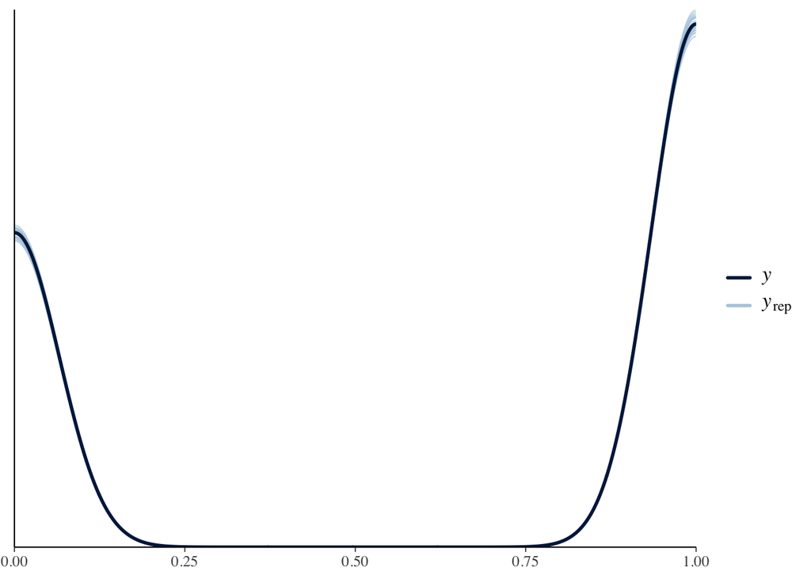

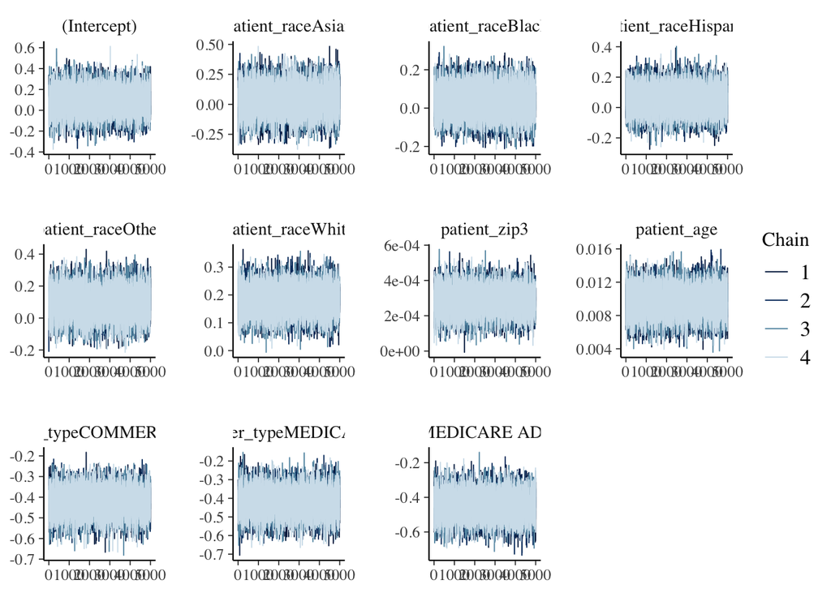

When we look at the traceplots for our various predictors we see random patterns which is what we want. There are no places where the chains get stuck or seem to follow a trend.

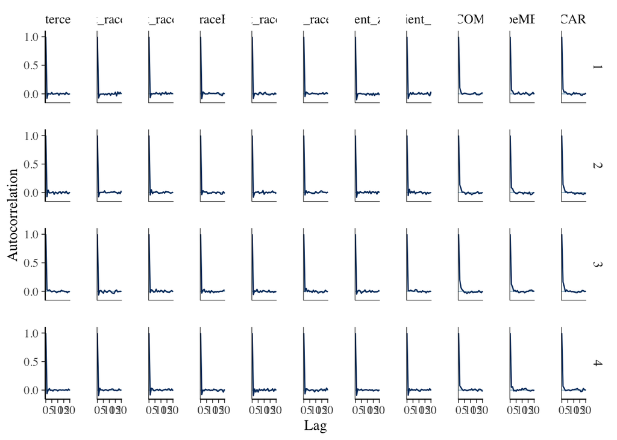

The autocorrelation plots tell us that for this model our chains drop down to no correlation quickly. This is a necessary assumption for our us to believe that the chains and sample are random.

# Error Metrics

```
## $confusion_matrix
##  y  0    1
##  0  5 4841
##  1 10 8050
##
## $accuracy_rates
##
## sensitivity      0.998759305
## specificity      0.001031779
## overall_accuracy 0.624128312
```

Our model has 99.8% sensitivity which means it is very good at giving true positives. However, specificity is very low with almost zero which means it was very bad at giving a true negative. Our overall accuracy is 62%. Since we did not use cross validation, we expect our model to do worse in a new dataset and have these measures decrease

We began our analysis of the dataset through a simple Bayesian logistic model. Before we did anything too complex, we thought it would be good to construct a model that, intuitively, made sense to us. For example, we asked ourselves the question what factors play the biggest role in a correct diagnosis of breast cancer? Then we decided to incorporate some predictors we thought could influence diagnosis from our prior knowledge, like race and type of insurance. Overall, our preliminary model helped inform us that our intuition for variables that affect diagnosis was on the right track. It can serve as a check for when we construct a Bayesian model that penalizes insignificant variables, but we might think they proive necessary information.

## Laplace Model

Initially, we aimed to employ a lasso model. However, this required our model’s likelihood to be normal, which was incompatible with the binomial nature of our data, given that we are dealing with a binary outcome variable. Instead, we use a laplace prior, with mean mu zero, and lambda standard deviation. Which for the purposes of our model, assumes that most predictors will be zero, and the rest will be distributed around zero. In terms of picking lambda, the autoscale function in stan_glm takes care of it, this means that it will adjust the scales of the priors according to the dispersion in the variables.

This model takes in every variable and then tries to minimize the RSS (residual sum of squares), which it does by pushing some variables it deems unimportant to near zero. This is appropriate, as we wanted to use it to see what variables were important for predicting breast cancer diagnosis. It also has full power on the priors of our predictors, which means that we do not have control as users. This is appropriate as we have not researched previous studies on this topic and have no prior beliefs.

$$\begin{array}{lrll}
\text{Data: } & Y_i | \beta_0, \beta_1,\beta_2,\beta_3,\beta_4 &
\stackrel{ind}{\sim} \text{Bern}(\pi_i) & \text{where }
\log\left(\frac{\pi_i}{1 - \pi_i}\right) = \beta_0 + \beta_1 X_i \\
&&& \text{equivalently, } \frac{\pi_i}{1 - \pi_i} =
e^{\beta_0 + \beta_1 X_i} \; \text{ and } \pi_i = \frac{e^{\beta_0 +
\beta_1 X_i}}{e^{\beta_0 + \beta_1 X_i} + 1} \\
&&& \\
\text{Priors: }
& \beta_{0c} & \sim N(m_0, s_0^2) \\
& \beta_1 & \sim N(m_1, s_1^2) \\
& \beta_2 & \sim N(m_2, s_2^2) \\
& \beta_3 & \sim N(m_3, s_3^2) \\
& \beta_4 & \sim N(m_4, s_4^2) \\
\end{array}$$

### Laplace Analysis

```r
laplace_model <- stan_glm(DiagPeriodL90D ~.,
                        data = combined_data_hs_clean,
                        family = binomial,
                        prior = laplace(autoscale = TRUE),
                        chains = 4,iter = 2500*2, cores = 2)
saveRDS(laplace_model,"laplace_modelreal.rds")
```

We originally wanted to use a lasso prior to auto filter our data, however, after analysis, we noticed it required a normal likelihood, but our data is binomial. We switched to a laplace prior, ans assumed the variables will be zero and pushed a lot of the original 77 variables to zero while keeping some important predictors.

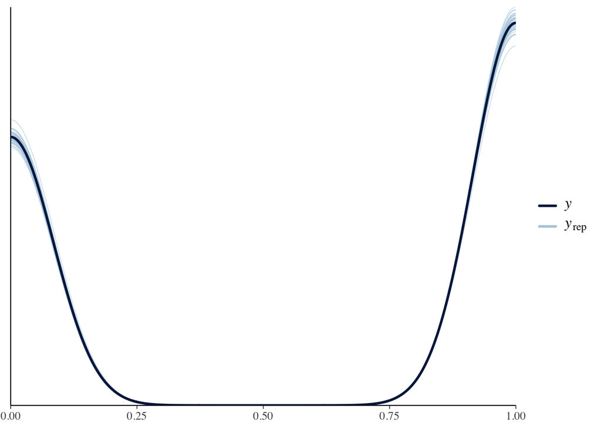

Using the pp_check we see that our possible models created by our model follow the data.

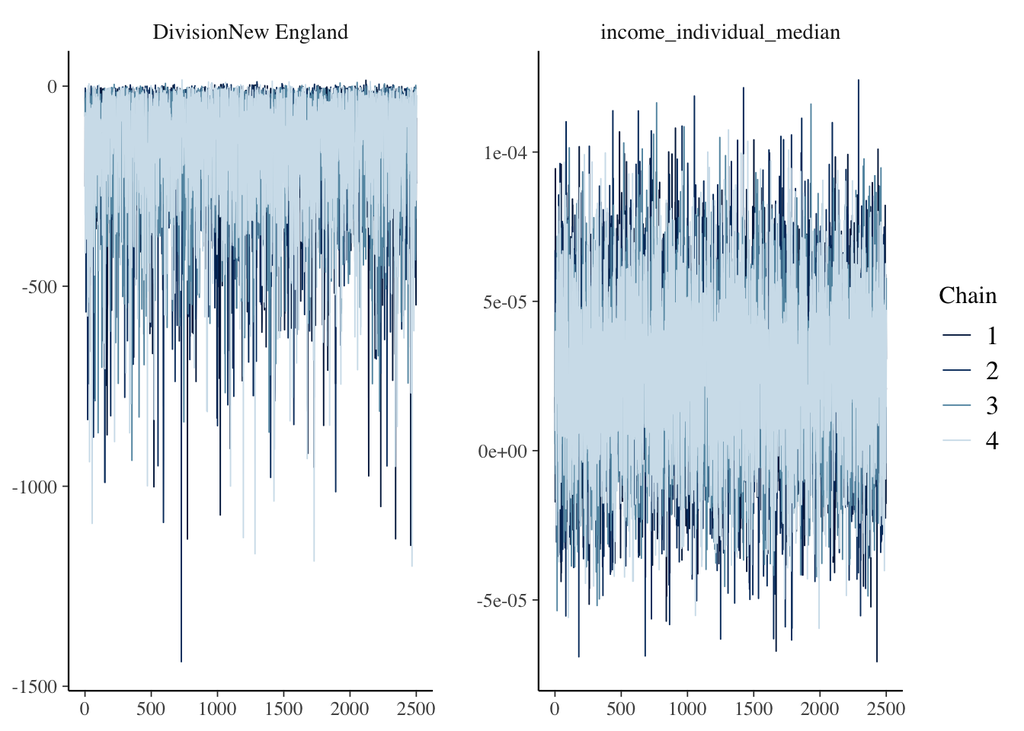

We see that the trace plots are very stable for one of the predictors that was kept in by the model (Division New england), and one that was kicked out (income_indivudal_median).

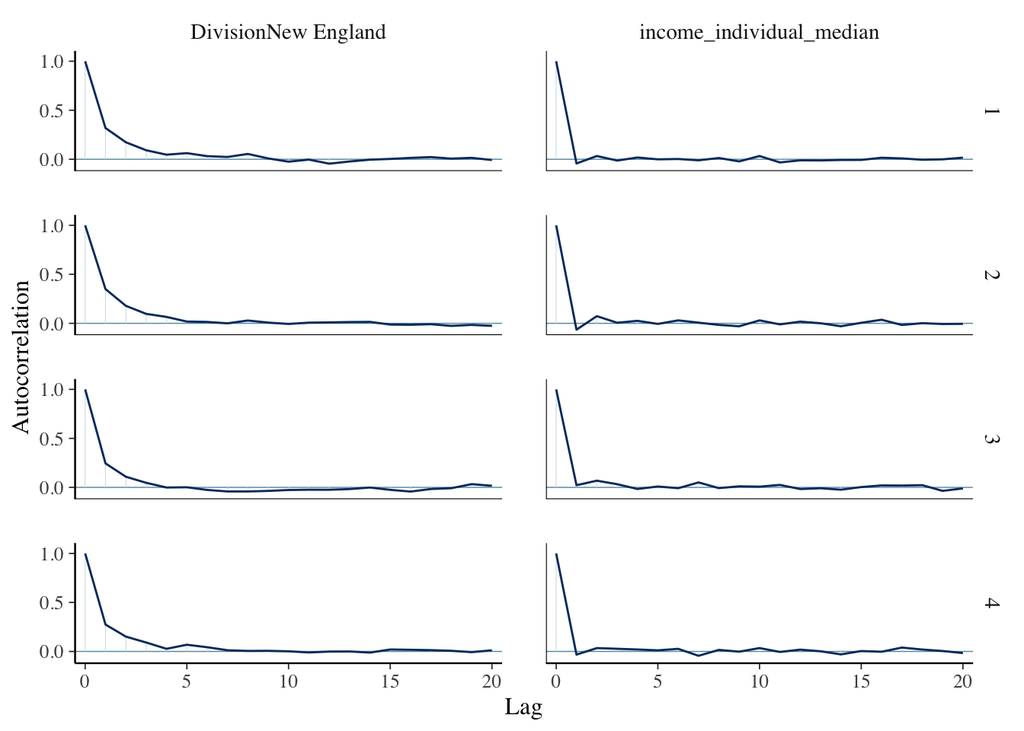

We also see low autocorrection within our chains, as by around 3-4 steps they are no longer dependent.

```
## # A tibble: 139 × 5
##    term        estimate std.error conf.low conf.high
##    <chr>          <dbl>     <dbl>    <dbl>     <dbl>
##  1 (Intercept)  12.7       91.8   -179.      195.
##  2 STATEAR       0.660      1.02    -0.995     2.37
##  3 STATEAZ      -0.472      0.857   -1.94      0.950
##  4 STATECA      -0.415      0.860   -1.91      0.983
##  5 STATECO       1.20       0.942   -0.364     2.74
##  6 STATECT      -1.18       0.812   -2.59      0.131
##  7 STATEDC       0.109      1.27    -2.04      2.30
##  8 STATEDE       0.0317     1.02    -1.75      1.76
##  9 STATEFL      -0.286      0.705   -1.53      0.834
## 10 STATEGA      -0.168      0.676   -1.38      0.930
## # ℹ 129 more rows
```

In this general this tidy plot, is a lot to look at but looking through we can see a large amount of estimates that have been sent to very small values, and many predictors credible interval cross zero.

```
## # A tibble: 12 × 6
##    term                         estimate    conf.low conf.high     odds     prob
##    <chr>                           <dbl>       <dbl>     <dbl>    <dbl>    <dbl>
##  1 DivisionNew England       -109.       -459.        -9.75e+0 3.72e-48 3.72e-48
##  2 STATEWI                     -1.54       -3.11      -7.52e-2 2.14e- 1 1.77e- 1
##  3 STATEIL                     -1.14       -2.40      -3.30e-2 3.20e- 1 2.42e- 1
##  4 payer_typeCOMMERCIAL        -0.334      -0.518     -1.44e-1 7.16e- 1 4.17e- 1
##  5 veteran                     -0.0603     -0.106     -1.48e-2 9.42e- 1 4.85e- 1
##  6 labor_force_participation   -0.0531     -0.0991    -7.86e-3 9.48e- 1 4.87e- 1
##  7 Ozone                       -0.0503     -0.0844    -1.70e-2 9.51e- 1 4.87e- 1
##  8 hispanic                    -0.0283     -0.0504    -7.43e-3 9.72e- 1 4.93e- 1
##  9 total_hospitals             -0.0114     -0.0200    -2.79e-3 9.89e- 1 4.97e- 1
## 10 density                     -0.000160   -0.000241  -8.02e-5 1.00e+ 0 5.00e- 1
## 11 patient_age                  0.00580     0.000325   1.13e-2 1.01e+ 0 5.01e- 1
## 12 STATEWY                    108.          6.87       4.69e+2 1.00e+47 1   e+ 0
```

```
##     threshold  specificity sensitivity
## 1        -Inf 0.0000000000   1.0000000
## 2  0.05801794 0.0006184292   1.0000000
## 3  0.11274799 0.0012368584   1.0000000
## 4  0.12702972 0.0012368584   0.9995662
## 5  0.15050068 0.0018552876   0.9995662
## 6  0.18460499 0.0024737168   0.9995662
## 7  0.21427378 0.0030921459   0.9995662
## 8  0.22386361 0.0037105751   0.9995662
## 9  0.23544988 0.0037105751   0.9991323
## 10 0.24735104 0.0043290043   0.9991323
```

```
## $confusion_matrix
##  y   0    1
##  0 272 1345
##  1 189 2116
##
## $accuracy_rates
##
## sensitivity      0.9180043
## specificity      0.1682127
## overall_accuracy 0.6088730
```

We notice an accuracy of 61% which is almost exactly the same as the simple Bayesian model we ran showing little difference between the two. We did not use any cross validation, therefore for an outside dataset, our model would be expected to score lower in sensitivity, specificity, and accuracy ratings. Overall, we see certain states appear as meaningful variables, along with division New England for geographical variables. We see some patient specific variables such as Hispanic, age, and commercial insurance or not. We also see a few zipcode specific variables such as total hospitals, ozone, veterans, labor force, and density.

# Code Appendix

```r
#Load packages
library(bayesrules)
library(pROC)
library(tidyr)
library(tidyverse)
library(ggplot2)
library(usmap)
library(sf)
library(rnaturalearth)
library(bayesplot)
library(broom)
library(broom.mixed)
library(glmnet)
library(rstan)
library(rstanarm)
library(plotly)
library(usethis)
```

```r
# Load the data
patient_data<-read.csv("Data/training.csv")
hospital_data<- read.csv("Data/Hospitals.csv")
population_data <- read.csv("Data/nst-est2019-alldata.csv")
population_data <- population_data %>%
  select(NAME, POPESTIMATE2018) %>%
  filter(NAME != c("United States", "Northeast Region", "Midwest Region", "South Region", "West Region"))
```

### Clean Code

```r
hospital_data_zip <- hospital_data %>%
  mutate(patient_zip3=substr(hospital_data$ZIP, 1,3))
hospital_data_zip$patient_zip3 <- strtoi(hospital_data_zip$patient_zip3)
```

```r
combined_data <- left_join(hospital_data_zip, patient_data, by = "patient_zip3", relationship = "many-to-many")
```

```r
length(unique(patient_data$patient_id))
length(unique(combined_data$patient_id))
```

```r
combined_data_hs <- combined_data %>%
  group_by(patient_id) %>%
  mutate(total_hospitals = n()) %>%
  distinct(patient_id, .keep_all = TRUE)
```

```r
# Select only the variables we need
combined_data_hs_clean <- combined_data_hs %>%
  ungroup() %>%
  select(-c(X,Y,OBJECTID,ID,NAME,ADDRESS,CITY,ZIP,ZIP4,TELEPHONE,TYPE,STATUS,TRAUMA,POPULATION,COUNTY,COUNTRY,COUNTYFIPS,LATITUDE,LONGITUDE,NAICS_CODE,NAICS_DESC,SOURCE,SOURCEDATE,VAL_METHOD,VAL_DATE,WEBSITE,STATE_ID,ALT_NAME,ST_FIPS,OWNER,TTL_STAFF,BEDS,TRAUMA,HELIPAD,patient_state,patient_zip3,patient_gender,breast_cancer_diagnosis_code,breast_cancer_diagnosis_desc,metastatic_cancer_diagnosis_code,metastatic_first_novel_treatment,metastatic_first_novel_treatment_type,patient_id))
```

```r
combined_data_hs_clean$Ozone <- as.numeric(combined_data_hs_clean$Ozone)
combined_data_hs_clean$PM25 <- as.numeric(combined_data_hs_clean$PM25)
combined_data_hs_clean$N02 <- as.numeric(combined_data_hs_clean$N02)
```

```r
combined_data_hs_clean <- na.omit(combined_data_hs_clean)
```

```r
# Adding abbreviations to the data
state_abbreviations <- data.frame(
  full_name = c("Alabama", "Alaska", "Arizona", "Arkansas", "California", "Colorado", "Connecticut",
                "Delaware", "District of Columbia", "Florida", "Georgia", "Hawaii", "Idaho", "Illinois",
                "Indiana", "Iowa", "Kansas", "Kentucky", "Louisiana", "Maine", "Maryland", "Massachusetts",
                "Michigan", "Minnesota", "Mississippi", "Missouri", "Montana", "Nebraska", "Nevada",
                "New Hampshire", "New Jersey", "New Mexico", "New York", "North Carolina", "North Dakota",
                "Ohio", "Oklahoma", "Oregon", "Pennsylvania", "Rhode Island", "South Carolina", "South Dakota",
                "Tennessee", "Texas", "Utah", "Vermont", "Virginia", "Washington", "West Virginia",
                "Wisconsin", "Wyoming", "Puerto Rico"),
  abbreviation = c("AL", "AK", "AZ", "AR", "CA", "CO", "CT", "DE", "DC", "FL", "GA", "HI", "ID", "IL",
                   "IN", "IA", "KS", "KY", "LA", "ME", "MD", "MA", "MI", "MN", "MS", "MO", "MT", "NE",
                   "NV", "NH", "NJ", "NM", "NY", "NC", "ND", "OH", "OK", "OR", "PA", "RI", "SC", "SD",
                   "TN", "TX", "UT", "VT", "VA", "WA", "WV", "WI", "WY", "PR")
)
```

```r
# Adding state population to the data
population_data_abv <- population_data %>%
  left_join(state_abbreviations, by = c("NAME" = "full_name")) %>%
  mutate(STATE = coalesce(abbreviation, "Unknown")) # If abbreviation is missing, mark it as "Unknown"
```

```r
# Creating full data set
combined_data_clean1 <- left_join(combined_data_hs_clean, population_data_abv, by = "STATE") %>%
  select(-c(NAME, abbreviation))

total_hospitals <- hospital_data %>%
  group_by(STATE) %>%
  summarise(total_hospitals = n()) %>%
  arrange(desc(total_hospitals))

full_dataset<-left_join(combined_data_clean1, total_hospitals, by = "STATE")

full_dataset$POPESTIMATE2018 <- as.numeric(full_dataset$POPESTIMATE2018)
full_dataset$total_hospitals.y <- as.numeric(full_dataset$total_hospitals.y)

# People per hospital data set
hospital_data_per_state <- full_dataset %>%
  mutate(
    ppl_per_hos = POPESTIMATE2018 / total_hospitals.y
  ) %>%
  select(STATE, ppl_per_hos) %>%
  group_by(STATE) %>%
  summarize(ppl_per_hos = mean(ppl_per_hos, na.rm = TRUE)) %>%
  filter(!STATE %in% c("AS", "GU", "MP", "PW", "VI"))
```

### Introduction

```r
# Plot for how many cases per state
full_dataset %>%
  count(STATE) %>%
  arrange(desc(n)) %>%
  ggplot(aes(x = reorder(STATE, n), y = n)) +
  geom_bar(stat = "identity") +
  theme(
    plot.title = element_text(size = 20),  # Adjust the title size
    axis.title.x = element_text(size = 16),  # Adjust x-axis label size
    axis.title.y = element_text(size = 16),  # Adjust y-axis label size
    axis.text.x = element_text(size = 15),  # Adjust x-axis tick label size
    axis.text.y = element_text(size = 8),  # Adjust y-axis tick label size
    legend.text = element_text(size = 14)  # Adjust legend text size
  ) +
  theme_minimal() +  # You can use a different theme if you prefer
  theme(
    plot.background = element_rect(fill = "white"),  # Set plot background color
    panel.grid.major = element_line(color = "lightgray"),  # Adjust major gridlines
    panel.grid.minor = element_blank()  # Remove minor gridlines
  ) +
  labs(
    title = "Cases per State in the Data Set",
    x = "State",
    y = "Cases"
  ) +
  coord_flip()
```

### Data Vizualizations

```r
# Hospitals by State
  ggplot(hospital_data_per_state, aes(x = reorder(STATE, ppl_per_hos), y = ppl_per_hos)) +
  geom_bar(stat = "identity") +
  theme(
    plot.title = element_text(size = 20),  # Adjust the title size
    axis.title.x = element_text(size = 16),  # Adjust x-axis label size
    axis.title.y = element_text(size = 16),  # Adjust y-axis label size
    axis.text.x = element_text(size = 15),  # Adjust x-axis tick label size
    axis.text.y = element_text(size = 8),  # Adjust y-axis tick label size
    legend.text = element_text(size = 14)  # Adjust legend text size
  ) +
  theme_minimal() +  # You can use a different theme if you prefer
  theme(
    plot.background = element_rect(fill = "white"),  # Set plot background color
    panel.grid.major = element_line(color = "lightgray"),  # Adjust major gridlines
    panel.grid.minor = element_blank()  # Remove minor gridlines
  ) +
  labs(
    title = "People per Hospitals by State",
    x = "State",
    y = "People per Hospital"
  ) +
  coord_flip()
```

```r
# Map of states that show people per hospital
hospital_data_per_state1 <- rename(combined_data_hs, state = STATE) %>%
  group_by(state) %>%
  filter(DiagPeriodL90D != "n/a") %>%
  summarise(percent_diag = mean(DiagPeriodL90D))


MapOfStatesTotalHospitals <- plot_usmap(data = hospital_data_per_state1, values = "percent_diag", region = "state") +
  labs(title = "US States by percentage of people who are diagnosised within 90 days",
       subtitle = "White being the lowest and blue being the highest") +
  scale_fill_continuous(low = "white",high = "blue", name = "Percentage of diagnoises within 90 days") +
  theme_minimal()

MapOfStatesTotalHospitals
```

```r
# Payer type by percentage of diagnosis within 90 days
health_data_perc <- patient_data %>%
  filter(!is.na(payer_type) & payer_type != "") %>%
  filter(!is.na(DiagPeriodL90D) & DiagPeriodL90D != "") %>%
  group_by(DiagPeriodL90D, payer_type) %>%
  summarise(count = n()) %>%
  mutate(percentage = count / sum(count) * 100)

health_data_perc %>%
  ggplot(aes(x = as.factor(DiagPeriodL90D), y = percentage, fill = payer_type)) +
  geom_bar(stat = "identity", position = "dodge", width = 0.7) +
  geom_text(aes(label = paste0(round(percentage), "%")), position = position_dodge(width = 0.7), vjust = -0.5) +
  labs(x = "Diagnosis", y = "Percentage", title = "Percentage of Payer Types within Diagnosis", fill = "Payer Type") +
  theme_minimal()
```

```r
#Diagnosed within 90 days by race
diag_race<-patient_data %>%
  filter(!is.na(patient_race) & patient_race != "") %>%
  filter(!is.na(DiagPeriodL90D) & DiagPeriodL90D != "") %>%
  group_by(patient_race) %>%
  summarise(avg_diag_90 = mean(DiagPeriodL90D))

ggplot(diag_race, aes(x=patient_race, y=avg_diag_90))+
  geom_point()+
  labs(x="Patient Race", y="Average Diagnosed Under 90 Days", title = "Diagnosed Under 90 Days by Race")+
  theme_minimal()
```

```r
# Access to Hospitals per State by Average Diagnosis Within 90 Days plot
full_dataset12<-full_dataset %>%
  count(STATE)

left_join(full_dataset, full_dataset12, by = "STATE") %>%
  mutate(
    ppl_per_hos = POPESTIMATE2018 / total_hospitals.y) %>%
  filter(!is.na(DiagPeriodL90D) & DiagPeriodL90D != "") %>%
  group_by(STATE, ppl_per_hos) %>%
  summarise(avg_diag_90 = mean(DiagPeriodL90D), num_cases = n()) %>%
  arrange(desc(avg_diag_90)) %>%
  ggplot()+
  geom_text(aes(x=ppl_per_hos, y=avg_diag_90, label = STATE, color = num_cases))+
  labs(x= "People per Hospital", y="Average Diagnosis Within 90 Days", title = "Access to Hospitals per State by Average Diagnosis Within 90 Days")+
  scale_color_continuous(name = "Number of Cases") +
  theme_minimal()
```

```r
# Age Density over Breast Cancer Diagnosis plot
full_dataset %>%
  filter(!is.na(DiagPeriodL90D)) %>%
  mutate(DiagPeriodL90D = factor(DiagPeriodL90D, labels = c("False", "True"))) %>%
  ggplot(aes(x = patient_age, fill = as.factor(DiagPeriodL90D)))+
  geom_density()+
  labs(title = "Age Density over Breast Cancer Diagnosis",
       x = "Age",
       y = "Density",
       fill = "Diagnosis within 90 Days")+
  theme_minimal()
```

### Preliminary Analysis

```r
# Model Code
diag_post3 <- stan_glm(
 DiagPeriodL90D  ~ patient_race + patient_zip3 + patient_age + payer_type,
  family = binomial,
  prior_PD = FALSE,
  data = patient_data,
  chains = 4, iter = 5000*2, seed = 84735, refresh = 0)
```

```r
# PP check
pp_check(diag_post3)
```

```r
# Trace plots
mcmc_trace(diag_post3)
```

```r
#ACF plots
mcmc_acf(diag_post3)
```

```r
#Classification summary
classification_summary(diag_post3, patient_data, cutoff = 0.5)
```

### Laplace Analysis

```r
combined_data_hs_clean <- combined_data_hs %>%
  ungroup() %>%
  select(-c(X,Y,OBJECTID,ID,NAME,ADDRESS,CITY,ZIP,ZIP4,TELEPHONE,TYPE,STATUS,TRAUMA,POPULATION,COUNTY,COUNTRY,COUNTYFIPS,LATITUDE,LONGITUDE,NAICS_CODE,NAICS_DESC,SOURCE,SOURCEDATE,VAL_METHOD,VAL_DATE,WEBSITE,STATE_ID,ALT_NAME,ST_FIPS,OWNER,TTL_STAFF,BEDS,TRAUMA,HELIPAD,patient_state,patient_zip3,patient_gender,breast_cancer_diagnosis_code,breast_cancer_diagnosis_desc,metastatic_cancer_diagnosis_code,metastatic_first_novel_treatment,metastatic_first_novel_treatment_type,patient_id))
```

```r
combined_data_hs_clean$Ozone <- as.numeric(combined_data_hs_clean$Ozone)
combined_data_hs_clean$PM25 <- as.numeric(combined_data_hs_clean$PM25)
combined_data_hs_clean$N02 <- as.numeric(combined_data_hs_clean$N02)
```

```r
combined_data_hs_clean <- na.omit(combined_data_hs_clean)
```

```r
# Code for laplace
laplace_model <- stan_glm(DiagPeriodL90D ~.,
                        data = combined_data_hs_clean,
                        family = binomial,
                        prior = laplace(autoscale = TRUE),
                        chains = 4,iter = 2500*2, cores = 2)
saveRDS(laplace_model,"laplace_modelreal.rds")
```

```r
# Read Model
hs_mod <- readRDS("laplace_modelreal.rds")
```

```r
# PP check
pp_check(hs_mod)
```

```r
# Trace Plot
mcmc_trace(hs_mod, pars = "DivisionNew England", "income_individual_median")
```

```r
#ACF plot
mcmc_acf(hs_mod, pars = "DivisionNew England", "income_individual_median")
```

```r
#Tidy
tidyLaPlace <- tidy(hs_mod, conf.int = 0.9, conf.level = 0.9)
(tidyLaPlace)
```

```r
# Make predictions (probability of success)
predictions <- predict(hs_mod, newdata = as.data.frame(combined_data_hs_clean), type = "response")
```

```r
# Create ROC curve
roc_curve <- roc(combined_data_hs_clean$DiagPeriodL90D, predictions) %>%
    coords(transpose = FALSE) %>%
  filter(sensitivity > 0.6)
roc_curve %>%
  head(10)
```

```r
#Classification summary
set.seed(43576)
classification_summary(hs_mod, combined_data_hs_clean, cutoff = 0.475)
```